# Ford GoBike System Data Exploration

## Bivariate Exploration

```python
numeric_vars = ['duration_sec','start_station_id','start_station_latitude','start_station_longitude',
                'end_station_id','end_station_latitude','end_station_longitude','bike_id','member_birth_year']
categoric_vars = ['user_type', 'member_gender','bike_share_for_all_trip']
```

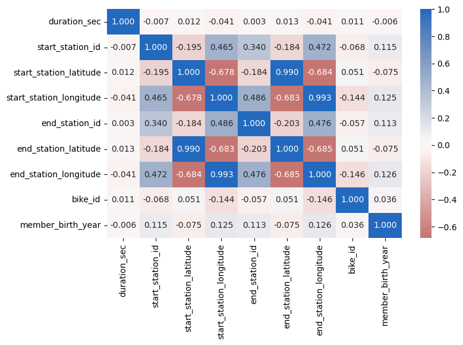

```python
# correlation plot
plt.figure(figsize = [8, 5])
sb.heatmap(df_bike[numeric_vars].corr(), annot = True, fmt = '.3f',
           cmap = 'vlag_r', center = 0)
plt.show()
```

```
df_bike.shape= (174952, 18)
df_bike_samp.shape= (500, 18)
```

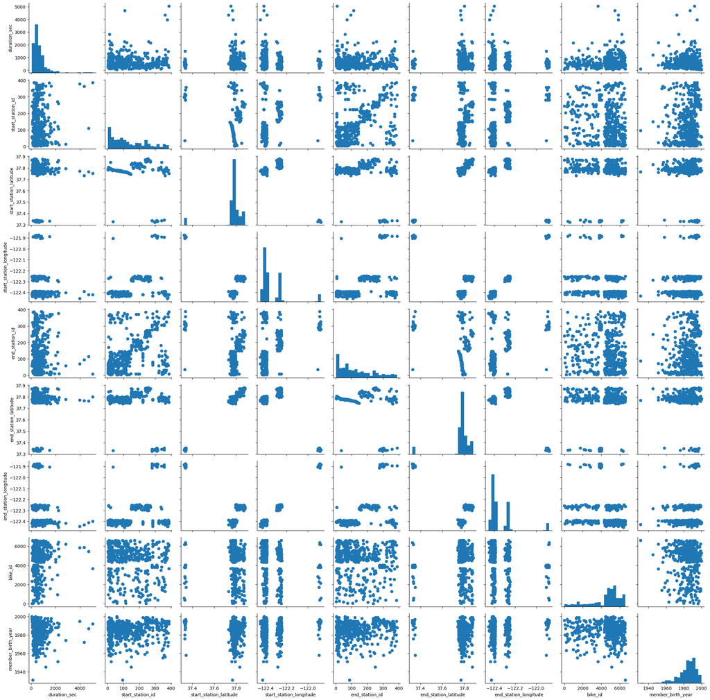

```python
# plot matrix: sample 500 diamonds so that plots are clearer and they render faster
print("df_bike.shape=",df_bike.shape)
df_bike_samp = df_bike.sample(n=500, replace = False)
print("df_bike_samp.shape=",df_bike_samp.shape)

g = sb.PairGrid(data = df_bike_samp, vars = numeric_vars)
g = g.map_diag(plt.hist, bins = 20);
g.map_offdiag(plt.scatter)
```

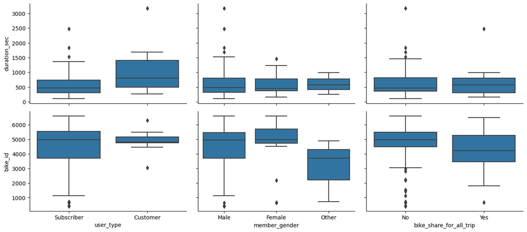

```python
# plot matrix of numeric features against categorical features.
# can use a larger sample since there are fewer plots and they're simpler in nature.

df_bike_samp = df_bike.sample(n=100, replace = False)


def boxgrid(x, y, **kwargs):
    """ Quick hack for creating box plots with seaborn's PairGrid. """
    default_color = sb.color_palette()[0]
    sb.boxplot(x=x, y=y, color=default_color)

plt.figure(figsize = [10, 10])
g = sb.PairGrid(data = df_bike_samp, y_vars = ['duration_sec', 'bike_id'], x_vars = categoric_vars,
                height = 3, aspect = 1.5)
g.map(boxgrid)
plt.show();
```

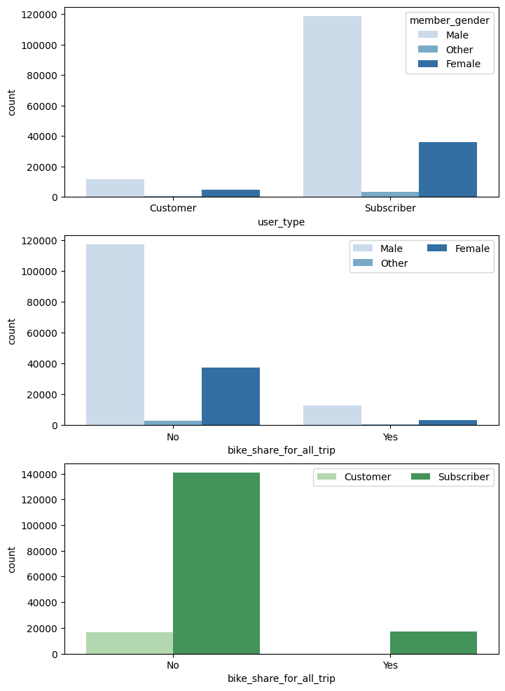

```python
# since there's only three subplots to create, using the full data should be fine.
plt.figure(figsize = [8, 12])

# subplot 1: user_type vs member_gender
plt.subplot(3, 1, 1)
sb.countplot(data = df_bike, x = 'user_type', hue = 'member_gender', palette = 'Blues')

# subplot 2: bike_share_for_all_trip vs. member_gender
ax = plt.subplot(3, 1, 2)
sb.countplot(data = df_bike, x = 'bike_share_for_all_trip', hue = 'member_gender', palette = 'Blues')
ax.legend(ncol = 2) # re-arrange legend to reduce overlapping

# subplot 3: bike_share_for_all_trip vs. user_type, use different color palette
ax = plt.subplot(3, 1, 3)
sb.countplot(data = df_bike, x = 'bike_share_for_all_trip', hue = 'user_type', palette = 'Greens')
ax.legend(loc = 1, ncol = 2) # re-arrange legend to remove overlapping

plt.show()
```

There doesn't seem to be that much interaction between df_bike user_id and member_gender, though proportionally it seems like there might be more subscriber *user_type* on the greatest *member_gender* (*male and female*). There are no interactions on *the bike_share_for_all_trip* and *gender_member*, the lower level for both *yes* and *no* is the *other*. It looks like there are more *male* in the member_gender.

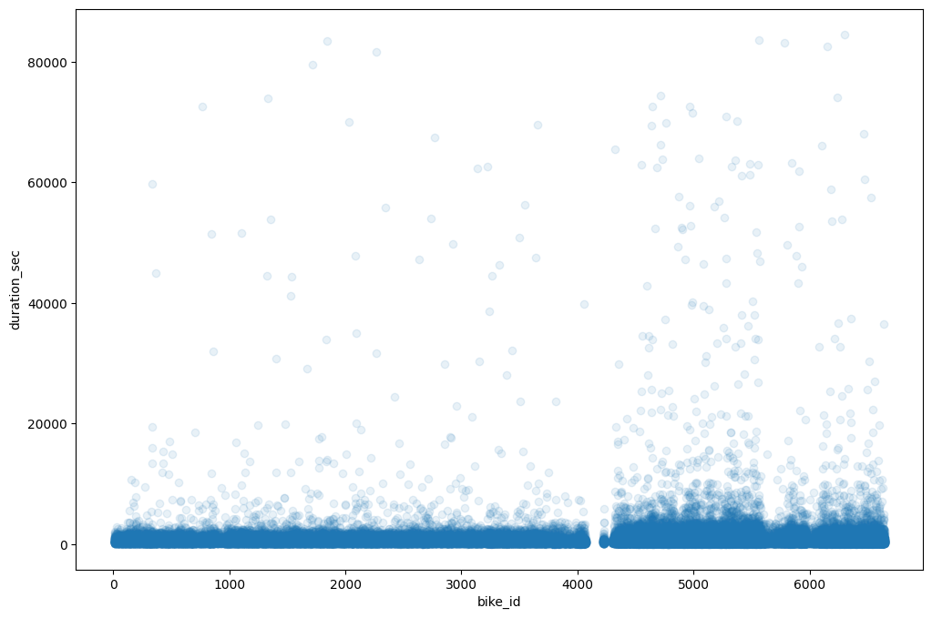

```python
# scatter plot of duration_sec vs. bike_id, with log transform on price axis

plt.figure(figsize = [12, 8])
plt.scatter(data = df_bike, x = 'bike_id', y = 'duration_sec', alpha = 1/10)
plt.xlabel('bike_id')
plt.ylabel('duration_sec')
```

Plotting duration seconds against bike id generates a relationship that looks much more concentrated on the base. After applying the transparent, the base is more concentrated with most of the values.

```python
def cuberoot_trans(x, inverse = False):
    """ quick function for computing cube root and cube operations """
    if not inverse:
        return x ** (1/3)
    else:
        return x ** 3
```

```python
# compute the logarithm of duration_sec to make multivariate plotting easier
def log_trans(x, inverse = False):
    """ quick function for computing log and power operations """
    if not inverse:
        return np.log10(x)
    else:
        return np.power(10, x)

df_bike['lod_duration_sec'] = df_bike['duration_sec'].apply(log_trans)
df_bike['cr_bike_id'] = df_bike['bike_id'].apply(cuberoot_trans)
```

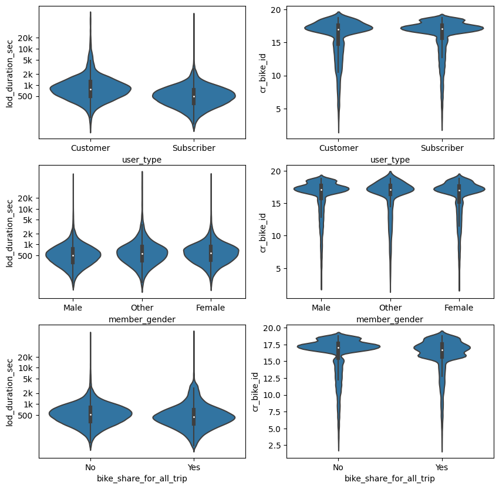

```python
# plot the categorical variables against duration_sec and bike_id again, this time
# with full data and variable transforms
bike_id_ticks = [2, 3, 5, 7, 9, 10, 15, 20]
fig, ax = plt.subplots(ncols = 2, nrows = 3 , figsize = [10,10])

for i in range(len(categoric_vars)):
    var = categoric_vars[i]
    sb.violinplot(data = df_bike, x = var, y = 'lod_duration_sec', ax = ax[i,0],
               color = def_color)
    ax[i,0].set_yticks(log_trans(np.array([500, 1e3, 2e3, 5e3, 1e4, 2e4])))
    ax[i,0].set_yticklabels([500, '1k', '2k', '5k', '10k', '20k'])
    sb.violinplot(data = df_bike, x = var, y = 'cr_bike_id', ax = ax[i,1],
               color = def_color)

plt.show()
```

```python
df_bike[['duration_sec','bike_id']].describe()
```

|  | duration_sec | bike_id |
| --- | --- | --- |
| count | 174952.000000 | 174952.000000 |
| mean | 704.002744 | 4482.587555 |
| std | 1642.204905 | 1659.195937 |
| min | 61.000000 | 11.000000 |
| 25% | 323.000000 | 3799.000000 |
| 50% | 510.000000 | 4960.000000 |
| 75% | 789.000000 | 5505.000000 |
| max | 84548.000000 | 6645.000000 |

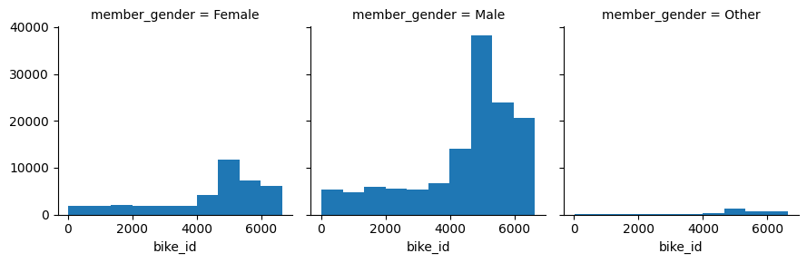

```python
gen_vars = ['Female', 'Male','Other']
vclasses = pd.api.types.CategoricalDtype(ordered=True, categories=gen_vars)
df_bike['member_gender'] = df_bike['member_gender'].astype(vclasses);

# Plot the Seaborn's FacetGrid
g = sb.FacetGrid(data = df_bike, col = 'member_gender')
g.map(plt.hist, "bike_id")
```

From the graph we can observe that the number of the male in the member_gender has the greatest number of bike_id, female being the second and the others has the least number of bike_id

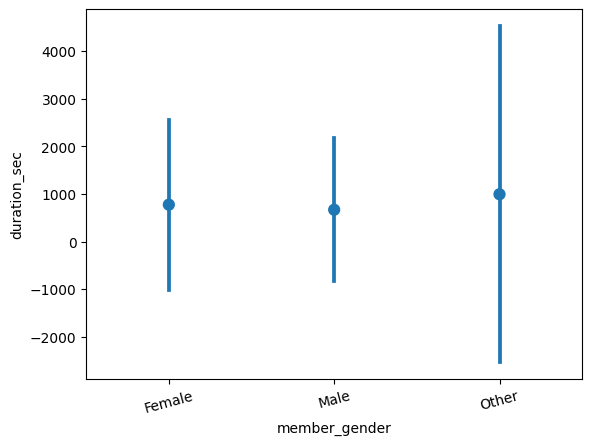

```python
sb.pointplot(data=df_bike, x='member_gender', y='duration_sec', color=def_color, errorbar='sd', linestyles="")
plt.xticks(rotation=15);
plt.ylabel('duration_sec')
```

From the graph we could see that, under the member gender column the male had the least duration second indcating the fasters.

### Talk about some of the relationships you observed in this part of the investigation. How did the feature(s) of interest vary with other features in the dataset?

There doesn't seem to be that much interaction between df_bike user_id and member_gender, though proportionally it seems like there might be more subscriber *user_type* on the greatest *member_gender* (*male and female*). There are no interactions on *the bike_share_for_all_trip* and *gender_member*, the lower level for both *yes* and *no* is the *other*. It looks like there are more *male* in the member_gender.

### Did you observe any interesting relationships between the other features (not the main feature(s) of interest)?

> Expected relationships were found in the association between the subscribe and customer of the user_type of bike dataset. Most of the bike user were subscribers.